# MusicFID

2026-10-26

Dataset: https://www.kaggle.com/datasets/catherinerasgaitis/mxmh-survey-results

Columnas disponibles:

- **Timestamp**: Momento en el que el usuario respondió la encuesta.
- **Age**: Edad del encuestado.
- **Primary.streaming.service**: Principal servicio de streaming usado por el encuestado.
- **Hours.per.day**: Horas del día dedicadas a escuchar música.
- **While.working**: Representa si el encuestado escucha música mientras trabaja o no.
- **Instrumentalist**: Representa si el encuentado toca un instrumento de forma habitual o no.
- **Composer**: Representa si el encuestado compone música o no.
- **Fav.genre**: Género favorito o principal del encuestado.
- **Exploratory**: Representa si el encuestado explora activamente nuevos artistas o géneros.
- **Foreign.languages**: Representa si el encuestado escucha habitualmente música con letras en un idioma que no domina.
- **BPM**: Pulsaciones por minuto o tempo del género favorito del encuestado.
- **Frequency..[Classical, Country, EDM, Folk, Gospel, Hip hop, Jazz, K pop, Latin, Lofi, Metal, Pop, R&B, Rap, Rock, Video game music]**: Frecuencia con la que el encuestado escucha cada uno de los géneros musicales listados (escala ordinal: Never, Rarely, Sometimes, Very frequently).
- **Anxiety**: Nivel de ansiedad autoinformado por el encuestado (escala de 0 a 10).
- **Depression**: Nivel de depresión autoinformado por el encuestado (escala de 0 a 10).
- **Insomnia**: Nivel de insomnio autoinformado por el encuestado (escala de 0 a 10).
- **OCD**: Nivel de TOC autoinformado por el encuestado (escala de 0 a 10).
- **Music.effects**: Representa si la música mejora o empeora los problemas de salud mental del encuestado o si no tiene efecto.
- **Permissions**: Permisos para publicar los datos.

## Lectura

Lectura inicial de los datos.

```r
raw_musicmh = read.csv("../inputs/mxmh_survey_results.csv", na.strings = c(""))
head(raw_musicmh)
```

```
##            Timestamp Age Primary.streaming.service Hours.per.day While.working
## 1 8/27/2022 19:29:02  18                   Spotify           3.0           Yes
## 2 8/27/2022 19:57:31  63                   Pandora           1.5           Yes
## 3 8/27/2022 21:28:18  18                   Spotify           4.0            No
## 4 8/27/2022 21:40:40  61             YouTube Music           2.5           Yes
## 5 8/27/2022 21:54:47  18                   Spotify           4.0           Yes
## 6 8/27/2022 21:56:50  18                   Spotify           5.0           Yes
##   Instrumentalist Composer        Fav.genre Exploratory Foreign.languages BPM
## 1             Yes      Yes            Latin         Yes               Yes 156
## 2              No       No             Rock         Yes                No 119
## 3              No       No Video game music          No               Yes 132
## 4              No      Yes             Jazz         Yes               Yes  84
## 5              No       No              R&B         Yes                No 107
## 6             Yes      Yes             Jazz         Yes               Yes  86
##   Frequency..Classical. Frequency..Country. Frequency..EDM. Frequency..Folk.
```

[output cut: 34 more lines]

Resumen

```
##   Timestamp              Age        Primary.streaming.service Hours.per.day
##  Length:736         Min.   :10.00   Length:736                Min.   : 0.000
##  Class :character   1st Qu.:18.00   Class :character          1st Qu.: 2.000
##  Mode  :character   Median :21.00   Mode  :character          Median : 3.000
##                     Mean   :25.21                             Mean   : 3.573
##                     3rd Qu.:28.00                             3rd Qu.: 5.000
##                     Max.   :89.00                             Max.   :24.000
##                     NA's   :1
##  While.working      Instrumentalist      Composer          Fav.genre
##  Length:736         Length:736         Length:736         Length:736
##  Class :character   Class :character   Class :character   Class :character
##  Mode  :character   Mode  :character   Mode  :character   Mode  :character
##
##
##
##
##  Exploratory        Foreign.languages       BPM           Frequency..Classical.
##  Length:736         Length:736         Min.   :0.00e+00   Length:736
##  Class :character   Class :character   1st Qu.:1.00e+02   Class :character
##  Mode  :character   Mode  :character   Median :1.20e+02   Mode  :character
##                                        Mean   :1.59e+06
##                                        3rd Qu.:1.44e+02
##                                        Max.   :1.00e+09
##                                        NA's   :107
##  Frequency..Country. Frequency..EDM.    Frequency..Folk.   Frequency..Gospel.
##  Length:736          Length:736         Length:736         Length:736
##  Class :character    Class :character   Class :character   Class :character
##  Mode  :character    Mode  :character   Mode  :character   Mode  :character
##
##
##
##
##  Frequency..Hip.hop. Frequency..Jazz.   Frequency..K.pop.  Frequency..Latin.
##  Length:736          Length:736         Length:736         Length:736
##  Class :character    Class :character   Class :character   Class :character
##  Mode  :character    Mode  :character   Mode  :character   Mode  :character
##
##
##
##
```

[output cut: 17 more lines]

```
##  Min.   : 0.000   Min.   : 0.000   Min.   : 0.000   Min.   : 0.000
##  1st Qu.: 4.000   1st Qu.: 2.000   1st Qu.: 1.000   1st Qu.: 0.000
##  Median : 6.000   Median : 5.000   Median : 3.000   Median : 2.000
##  Mean   : 5.838   Mean   : 4.796   Mean   : 3.738   Mean   : 2.637
##  3rd Qu.: 8.000   3rd Qu.: 7.000   3rd Qu.: 6.000   3rd Qu.: 5.000
##  Max.   :10.000   Max.   :10.000   Max.   :10.000   Max.   :10.000
##
##  Music.effects      Permissions
##  Length:736         Length:736
##  Class :character   Class :character
##  Mode  :character   Mode  :character
##
##
##
##
```

## Preprocesamiento

### Limpieza

Importar las herramientas:

```r
source("scripts/preprocessing.R")
```

1. Limpieza de columnas que solo aportan ruido, en concreto, Timestamp y Permissions. El día que se envió el formulario y si el encuestado da permiso no aportan información al estudio.

**Nota**: Si el encuestado no da permiso para que se publiquen los datos entonces no se encuentra en le dataset, todos los que aparecen han consentido la publicación de sus resultados.

```r
musicmh = remove_noise_columns(raw_musicmh)
musicmh = convert_columns_to_factor(musicmh)

summary(musicmh)
```

```
##       Age        Hours.per.day    While.working Instrumentalist Composer
##  Min.   :10.00   Min.   : 0.000   No  :154      No  :497        No  :609
##  1st Qu.:18.00   1st Qu.: 2.000   Yes :579      Yes :235        Yes :126
##  Median :21.00   Median : 3.000   NA's:  3      NA's:  4        NA's:  1
##  Mean   :25.21   Mean   : 3.573
##  3rd Qu.:28.00   3rd Qu.: 5.000
##  Max.   :89.00   Max.   :24.000
##  NA's   :1
##   Fav.genre         Exploratory Foreign.languages      BPM
##  Length:736         No :211     No  :328          Min.   :0.00e+00
##  Class :character   Yes:525     Yes :404          1st Qu.:1.00e+02
##  Mode  :character               NA's:  4          Median :1.20e+02
##                                                   Mean   :1.59e+06
##                                                   3rd Qu.:1.44e+02
##                                                   Max.   :1.00e+09
##                                                   NA's   :107
##      Frequency..Classical.      Frequency..Country.        Frequency..EDM.
##  Never          :169       Never          :343      Never          :307
##  Rarely         :259       Rarely         :233      Rarely         :194
##  Sometimes      :200       Sometimes      :111      Sometimes      :146
##  Very frequently:108       Very frequently: 49      Very frequently: 89
##
##
##
##         Frequency..Folk.       Frequency..Gospel.      Frequency..Hip.hop.
##  Never          :292     Never          :535      Never          :181
##  Rarely         :221     Rarely         :135      Rarely         :214
##  Sometimes      :145     Sometimes      : 52      Sometimes      :218
##  Very frequently: 78     Very frequently: 14      Very frequently:123
##
##
##
##         Frequency..Jazz.       Frequency..K.pop.       Frequency..Latin.
##  Never          :261     Never          :416     Never          :443
##  Rarely         :247     Rarely         :176     Rarely         :172
##  Sometimes      :175     Sometimes      : 67     Sometimes      : 88
##  Very frequently: 53     Very frequently: 77     Very frequently: 33
##
##
##
```

[output cut: 17 more lines]

```
##  Never          :236           Min.   : 0.000   Min.   : 0.000
##  Rarely         :197           1st Qu.: 4.000   1st Qu.: 2.000
##  Sometimes      :186           Median : 6.000   Median : 5.000
##  Very frequently:117           Mean   : 5.838   Mean   : 4.796
##                                3rd Qu.: 8.000   3rd Qu.: 7.000
##                                Max.   :10.000   Max.   :10.000
##
##     Insomnia           OCD           Music.effects
##  Min.   : 0.000   Min.   : 0.000   Worsen   : 17
##  1st Qu.: 1.000   1st Qu.: 0.000   No effect:169
##  Median : 3.000   Median : 2.000   Improve  :542
##  Mean   : 3.738   Mean   : 2.637   NA's     :  8
##  3rd Qu.: 6.000   3rd Qu.: 5.000
##  Max.   :10.000   Max.   :10.000
##
```

Las siguientes variables presenta valores ausentes que hay que tratar: Age(1), While.working(3), Instrumentalist(4), Composer(1), Foreign.languages(4), BPM(107), Music.effects(8).

La variable BPM presenta valores claramente outliers, con valores desde 0 hasta 10<sup>9</sup>.

3. Eliminar muestras con muchos atributos NA.

```r
sorted_nas = return_sorted_na_per_row_if_present(musicmh)
head(sorted_nas)
```

```
##   Age Hours.per.day While.working Instrumentalist Composer Fav.genre
## 1  21             1          <NA>            <NA>     <NA>     K pop
## 2  NA             3           Yes              No       No   Hip hop
## 3  42             0          <NA>              No       No      Rock
## 4  21             2           Yes              No       No       EDM
## 5  67             1            No              No       No      Rock
## 6  18             3           Yes             Yes      Yes     Latin
##   Exploratory Foreign.languages BPM Frequency..Classical. Frequency..Country.
## 1         Yes              <NA>  NA                Rarely              Rarely
## 2         Yes               Yes  NA                Rarely               Never
## 3          No               Yes  NA                Rarely              Rarely
## 4          No               Yes  NA                Rarely              Rarely
## 5          No                No  NA             Sometimes           Sometimes
## 6         Yes               Yes 156                Rarely               Never
##   Frequency..EDM. Frequency..Folk. Frequency..Gospel. Frequency..Hip.hop.
```

[output cut: 34 more lines]

Por lo tanto, al tener la muestra con más NA presentes 6, hacer una imputación de tantos atributos sería generar una muestra muy artificial y es mejor eliminarla.

```r
musicmh = anti_join(musicmh, sorted_nas[1,])
```

[output not shown]

```r
dim(musicmh)
```

```
## [1] 735  30
```

4. Codificar variables nominales y ordinales

```r
musicmh = ordinal_cols_encoder(musicmh)
```

### Tratamiento de valores ausentes y outliers

Es posible que el no saber el género músical tenga relevancia en la salud mental de las personas, por lo que es interesante estudiar si es relevante que las personas conozcan el BPM de sus generos favoritos.

## Exploración

Outliers

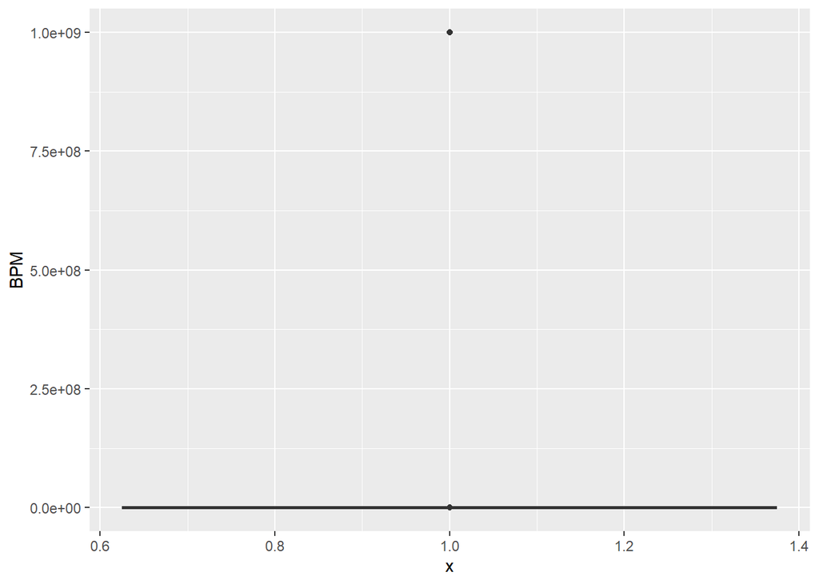

```r
library(ggplot2)
library(corrplot)
ggplot(data=musicmh,aes(x=1,y=BPM))+geom_boxplot()
```

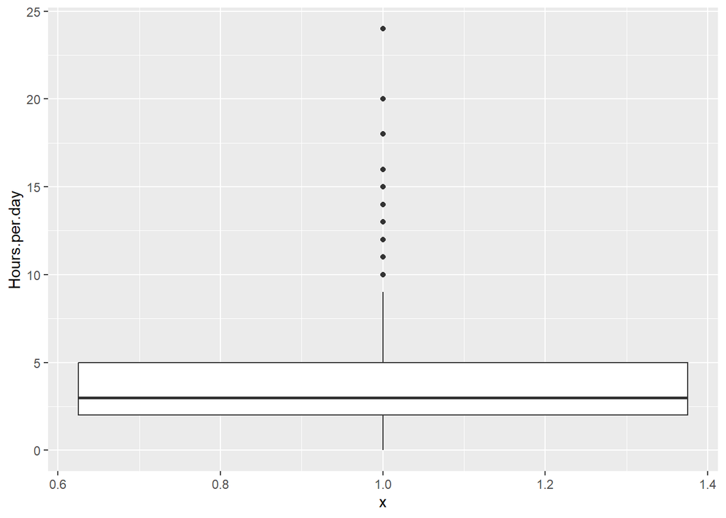

```r
ggplot(data=musicmh,aes(x=1,y=Hours.per.day))+geom_boxplot()
```

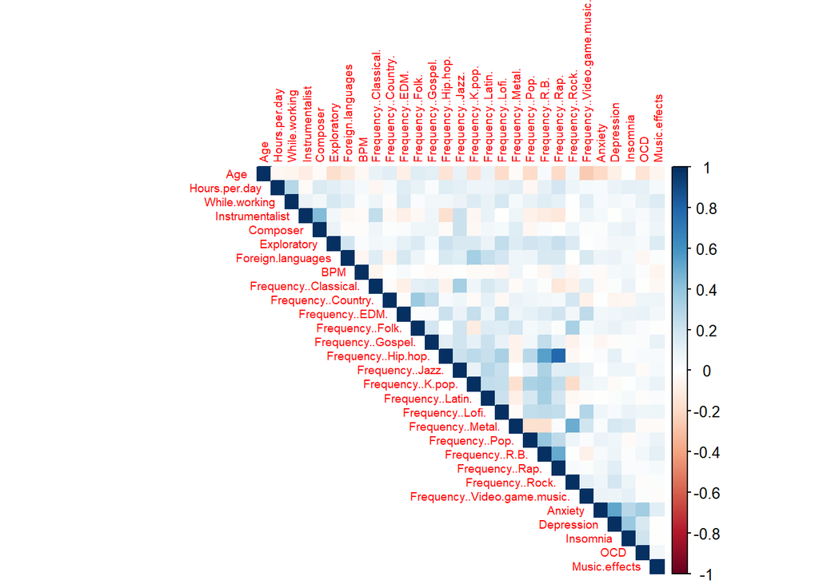

```r
corrplot(cor(musicmh[, !names(musicmh) %in% c("Fav.genre", "Primary.streaming.service")], method = "pearson", use = "complete.obs"),
         method = "color",
         type = "upper",
         tl.cex = 0.6)
```

## Visualización - Pie Chart

En este apartado hemos creado un pie chart para poder visualizar el número de personas que tiene cada género (ya que cada persona tiene un solo género favorito de música), para ello, hemos realizado un filtrado de los datos agrupando por género y contando el número de personas de cada uno, para después dibujarlo con plot_ly

```r
#
library(plotly)
library(gapminder)
library(dplyr)
df <- musicmh
pie_data <- df %>%
  filter(!is.na(Fav.genre)) %>%
  group_by(Fav.genre) %>%
  summarise(n_personas = n(), .groups = "drop")

fig <- pie_data %>%
  plot_ly(
    labels = ~Fav.genre,
    values = ~n_personas,
    type = "pie",
    textinfo = "label+percent",
    hoverinfo = "label+value+percent"
  ) %>%
  layout(title = "Género favorito")

fig
```

[interactive chart not shown]

Puede verse que el género mayoritario es Rock (188 oyentes), seguido de Pop (114) y Metal (88), a su vez se puede ver que el género Latin y Gospel son los menos escuchados de forma bastante significativa (solo cuentan con 3 y 6 oyentes respectivamente).

## Visualización - Dispersión por niveles de trastorno

En este apartado hemos utilizado gráficos de dispersión para ver como se distribuyen los niveles percibidos de cada trastorno frente a las horas escuchadas de cada género, el tamaño de punto corresponde con el número de personas que escuchan un género un número determinado de horas y que han percibido un nivel determinado del trastorno. Al tener muchos géneros hemos decidido descartar todos aquellos que no superaran el 5% de representación total en número de personas, en este caso el corte queda en 37 personas.

```r
num_people <- df %>%
  filter(!is.na(Fav.genre)) %>%
  group_by(Fav.genre) %>%
  filter(n() >= 37) %>%
  ungroup() %>%
  group_by(Hours.per.day, Anxiety, Fav.genre) %>%
  summarise(n_personas = n(), .groups = "drop")

fig <- num_people %>%
  plot_ly(
    x = ~Hours.per.day,
    y = ~Anxiety,
    size = ~n_personas,
    color = ~Fav.genre,
    type = "scatter",
    mode = "markers",
    sizes = c(10, 60),
    marker = list(opacity = 0.6, sizemode = "diameter"),
    text = ~paste("Personas:", n_personas),
    hoverinfo = "text+x+y"
  )

fig
```

[interactive chart not shown]

En el caso de la ansiedad podemos ver que los oyentes de Rock cuentan con niveles de ansiedad superiores a 5 en su mayoría. Podemos ver una gran burbuja de personas que tienen un nivel 7 de ansiedad y que escuchan diariamente 2 horas de rock. A su vez podemos observar un outlier, ya que hay una persona que escucha al día 24 horas de Rock. Podemos también observar que las personas interesadas en la música clásica escuchan dichas canciones durante menos tiempo que el resto de géneros.

Eliminación de filas con valor NA en la variable a predecir en clasificación.

```r
musicmh_class = remove_na_target_rows_classification(musicmh)
```